# HW 2: Анализ маркетинговой кампании

Барышев Матвей, mibaryshev

## Задача

Мы разработали новую маркетинговую кампанию, запустили её на тест в одном из наших магазинов и перед тем, как расширять ее на остальные магазины, нам нужно проанализировать результаты.

Основной задачей будет провести разведывательный анализ данных, включая проверку взаимосвязей с помощью статистических тестов, а также применить деревья решений для задачи классификации – предсказать, примет ли клиент предложение в рамках кампании.

Оформить результат в виде дэшборда с основными результатами + отчета с пояснениями (какие гипотезы проверены, какие группы исследованы и почему, какие предсказания в каких группах получились).

### Загрузка данных и преобразование

```r
library(dplyr)
library(ggplot2)
library(ggstatsplot)
library(gridExtra)
library(rpart)
library(rpart.plot)

marketing = read.csv("~/shared/minor2_2022/1-Intro/hw2/marketing_campaign.csv")
```

Первым делом преобразуем переменную Response в факторную переменную. Так же преобразуем переменные Marital_Status и Education. Переменную Dt_Customer, обозначающую дату, преобразуем к типу Date. Для более удобной работы колонка Year_Birth была преобразована в колонку Age, отображающую возраст клиента. Расчёт ведётся относительно 2014г из-за того, что крайняя дата в колонке Dt_Customer (дата, когда респондент стал клиентом компании) 28 июня 2014г. Была создана колонка TotalSpent, которая включает в себя все расходы клиента. Также в ходе анализа были обнаружены и удалены выбросы.

```r
marketing$Response = as.factor(marketing$Response)
marketing$AcceptedCmp = as.factor(marketing$AcceptedCmp)
marketing$Education = as.factor(marketing$Education)
marketing$Marital_Status = as.factor(marketing$Marital_Status)

marketing$Dt_Customer = lubridate::dmy(marketing$Dt_Customer)

colnames(marketing)[2] = "Age"
marketing = mutate(marketing, Age = 2014 - Age)

marketing = mutate(marketing, TotalSpent = MntWines + MntFruits + MntMeatProducts + MntFishProducts + MntSweetProducts)
# Удаление выбросов:
marketing = marketing %>% filter(Age < 100 & Income < 600000)
marketing = marketing %>% filter(TotalSpent > 250 | Income < 150000)
```

### Исследовательские вопросы и тесты

#### Вопрос 1

**Существует ли какая-то взаимосвязь между доходами и расходами наших клиентов?**

Для начала построим графики распределения доходов и расходов среди наших покупателей.

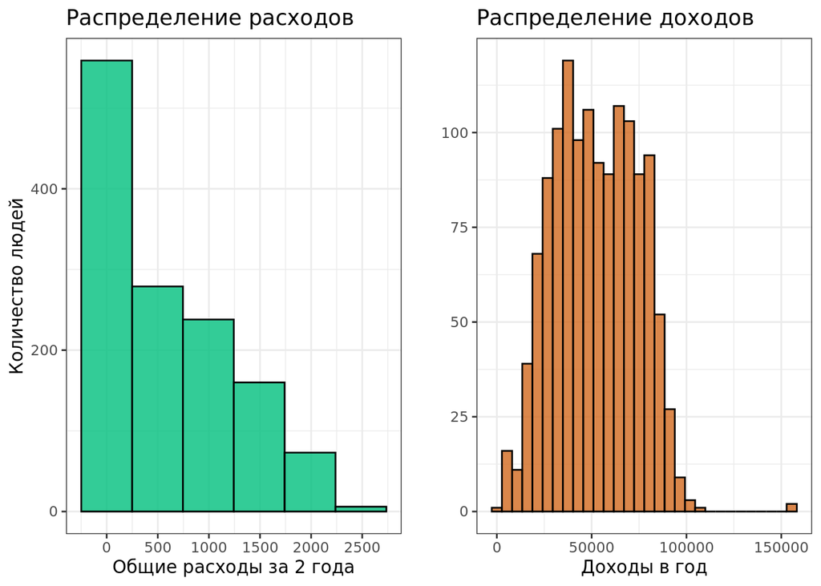

```r
a = ggplot() +
  geom_histogram(data = marketing, aes(x = TotalSpent), bins = 6, color = "black", fill = "#00BF7D", alpha = 0.8) +
  scale_x_continuous(breaks=seq(0,2500,by=500)) +
  ggtitle("Распределение расходов") +
  ylab("Количество людей") +
  xlab("Общие расходы за 2 года") +
  theme_bw()

b = ggplot() +
  geom_histogram(data = marketing, aes(x = Income), color = "black", fill = "#D2691E", alpha = 0.8) +
  ggtitle("Распределение доходов") +
  xlab("Доходы в год") +
  ylab('') +
  theme_bw()
grid.arrange(a, b, ncol = 2, nrow = 1)
```

Построим диаграмму рассеивания по этим двум переменным для наглядной визуализации зависимости.

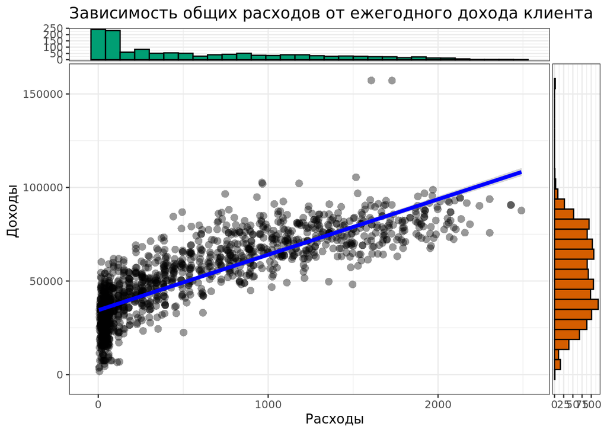

```r
ggscatterstats(data = marketing, x = TotalSpent, y = Income,
               type = 'p', centrality.para = 'mean', marginal.type = 'histogram',
               results.subtitle = FALSE,
               title = 'Зависимость общих расходов от ежегодного дохода клиента',
               xlab = 'Расходы',
               ylab = 'Доходы',
               ggtheme = ggplot2::theme_bw())
```

На графике можно заметить некоторую прямую зависимость этих двух переменных. Для подтверждения этого факта проведём корреляционный тест.

```r
cor.test(marketing$Income, marketing$TotalSpent)
```

[output not shown]

По результатам теста коэффициент корреляции равен 0.83. Это подтверждает гипотезу, что между данными двумя переменными существует сильная прямая зависимость, причем она статистически значима, т.к p-value намного меньше 0.05.

Такое широкое распределение доходов наших респондентов позволяет понять, что наша кампания охватывает большую группу лиц, что помогает увеличивать прибыль.

#### Вопрос 2

**Правда ли, что пользователи, которые откликнулись на предыдущую кампанию, чаще откликаются и на нынешнюю кампанию?**

Для наглядности построим график, учитывающий отклики на прошлую компанию и нынешнюю.

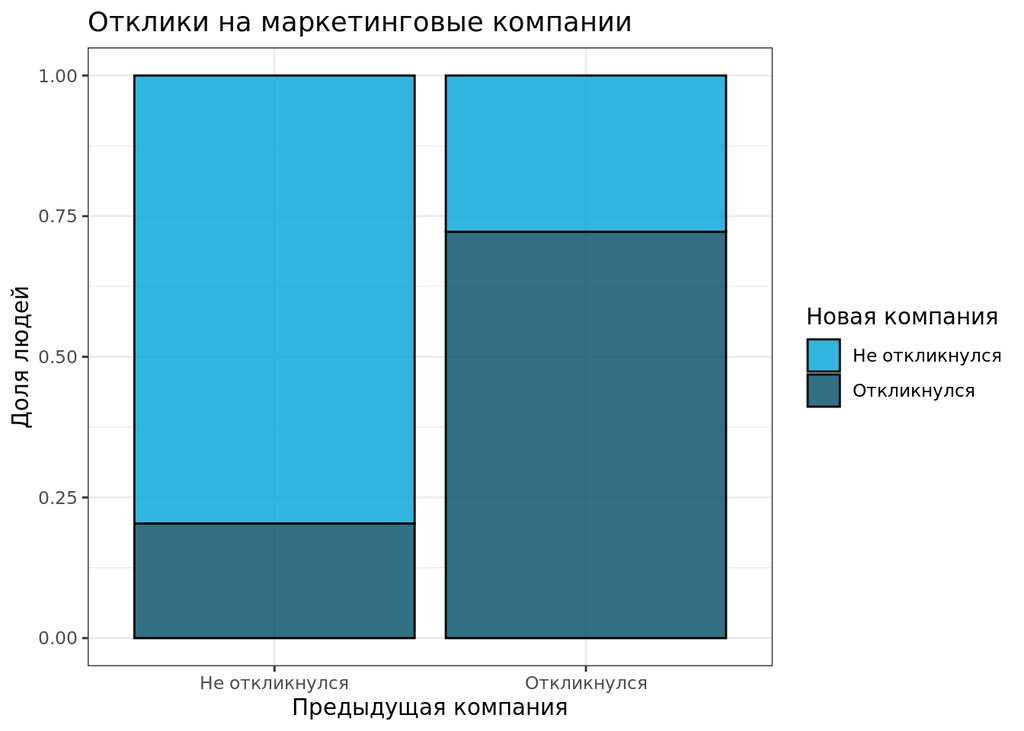

```r
ggplot() +
  geom_bar(data = marketing, aes(x = AcceptedCmp, fill = Response), position = "fill", alpha = 0.8, color = 'black') +
  ggtitle("Отклики на маркетинговые компании") +
  ylab('Доля людей') +
  xlab('Предыдущая компания') +
  scale_x_discrete(labels = c("Не откликнулся", "Откликнулся")) +
  ggthemes::scale_fill_economist(name = "Новая компания", labels = c("Не откликнулся", "Откликнулся")) +
  theme_bw()
```

Из графика явно видно, что большинство(~75%) среди тех, кто откликнулся на первую компанию, откликнулись и на текущую.

Проведём тест хи-квадрат для выявления зависимости.

```r
chisq.test(marketing$AcceptedCmp, marketing$Response)
```

[output not shown]

В результате теста p-value получился < 2.2e-16, что означает статистически значимую зависимость между двумя данными переменными. Гипотеза, что пользователи, которые откликнулись на предыдущую кампанию, чаще откликаются и на нынешнюю кампанию, подтверждена.

### Предсказание отклика на кампанию

Для предсказания отклика на нашу маркетинговую кампанию мы будем пользоваться деревом решений.

Для начала построим дерево для предсказания переменной Response по всем остальным переменным с ограничением cp = 0.001. Также разобьём наш датасет на тренировочную и тестовую выборки.

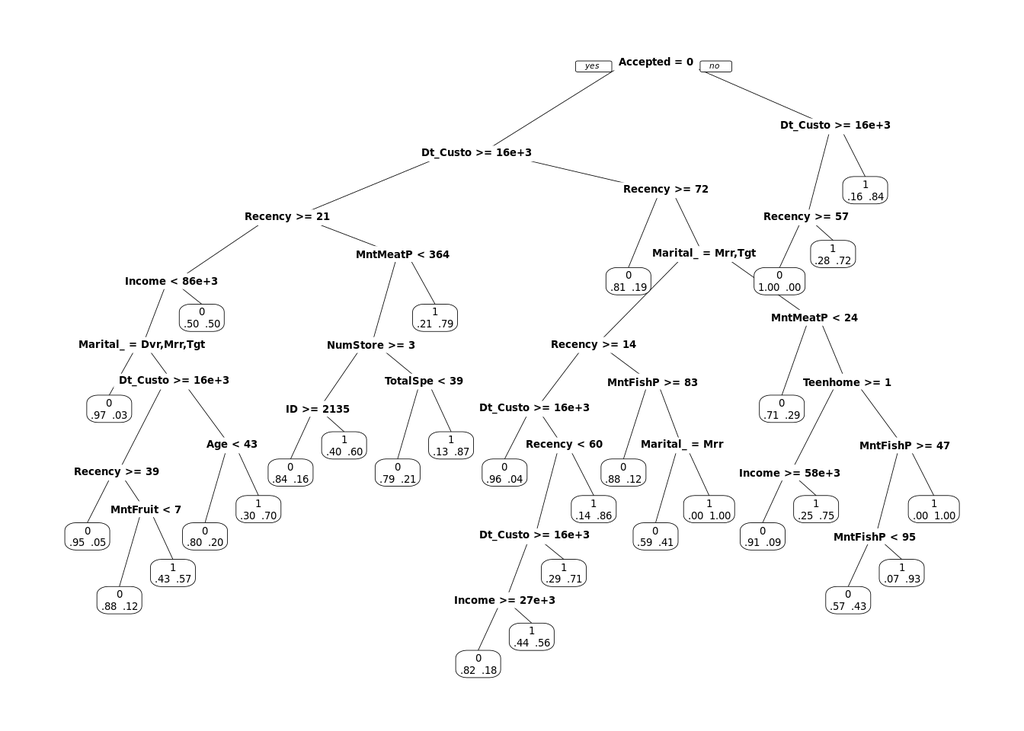

```r
set.seed(123)
marketing_train = sample_frac(marketing, 0.8)
marketing_test = marketing %>% anti_join(marketing_train)

tree = rpart(Response ~ ., data = marketing_train, control = rpart.control(cp=0.001))
prp(tree, extra =4)
```

Сразу заметно, что наше дерево получилось слишком большим. Это может свидетельствовать о том, что наша модель переобучается, что может привести к плохим результатам на новых данных. Проверим это на тренировочной и тестовой выборках.

```r
pred_train = predict(tree, marketing_train, type = "class")
t_train = table(pred_train, marketing_train$Response)
(t_train[1,1] + t_train[2,2])/sum(t_train)
```

```
## [1] 0.8773764
```

```r
pred_test = predict(tree, marketing_test, type = "class")
t_test = table(pred_test, marketing_test$Response)
(t_test[1,1] + t_test[2,2])/sum(t_test)
```

```
## [1] 0.7680608
```

Отсюда видим, что результат отличается более чем на 0.1! Это как раз свидетельствует о том, что наша модель ‘привыкла’ к тренировочным данным и заметно хуже работает на новых.

Вычислим оптимальное значение cp, при котором значение ошибки xerror минимально, чтобы избежать переобучения.

```r
cp_tbl = printcp(tree)

min_cp = cp_tbl %>%
  as.data.frame() %>%
  arrange(xerror) %>%
  head(n = 1)
min_cp
```

[output not shown]

Построим дерево с найденным значением cp = 0.011.

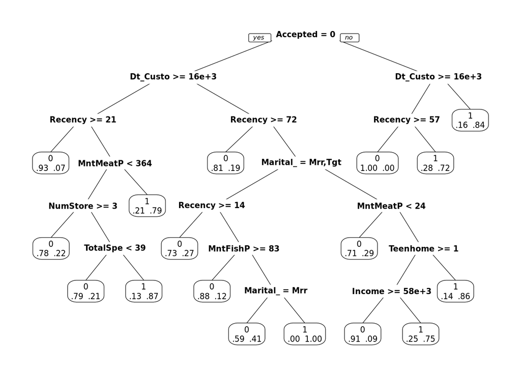

```r
tree = rpart(Response ~ . - ID, data = marketing_train, control = rpart.control(cp=0.011))
prp(tree, extra = 4)
```

Данное дерево уже не такое объёмное как предыдущее.

Проверим нашу модель на качество предсказания, вычислив Accuracy.

```r
pred_train = predict(tree, marketing_train, type = "class")
t_train = table(pred_train, marketing_train$Response)
(t_train[1,1] + t_train[2,2])/sum(t_train)
```

```
## [1] 0.8602662
```

```r
pred_test = predict(tree, marketing_test, type = "class")
t_test = table(pred_test, marketing_test$Response)
(t_test[1,1] + t_test[2,2])/sum(t_test)
```

```
## [1] 0.8174905
```

Точность нашей модели на тренировочных и тестовых данных не так сильно отличается друг от друга, как в случае с переобученной моделью.

Наше получившееся дерево решений предсказывает отклик на маркетинговую кампанию с точностью ~0.82.

Если рассмотреть получившееся дерево детальнее, то можно заметить, что модель обращает внимание в первую очередь на то, принял ли клиент нашу прошлую кампанию. Как уже доказали выше этот фактор действительно является важным и люди, которых заинтересовала наша первая кампания с большой вероятностью были заинтересованы и нынешней. Также модель учитывает дату, когда респондент стал клиентом компании и количество дней с момента последней покупки. Разбиение по данным переменным встречается как в правой, так и в левой части дерева. Следовательно, данные переменные тоже являются важными для предсказания отклика.

## Общие выводы

Исходя из проведённого анализа, можно сделать вывод, что большинство клиентов, которые были заинтересованы в нашей прошлой кампании, остались заинтересованы в новой кампании. Также нам удалось привлечь хорошее количество новых клиентов. А исходя из полученного дерева решений можно сказать, что отклик на прошлую кампанию стал одним из ключевых факторов для предсказания отклика на новую. Построенное дерево также помогает нам понять, что в предсказании отклика могут помочь такие переменные как дата регистрации, количество дней с момента последней покупки, количество того или иного товара, а также семейное положение. Ещё нам удалось выяснить, что наши клиенты имеют разные уровни доходов и расходов, причём они напрямую зависят друг от друга. Это показывает, что наши маркетинговые кампании ориентированы на большой круг лиц, что помогает привлекать больше клиентов.